# SL Homework 3

Joshua Ingram

September 20, 2019

## Problem 1

```r
head(advertising, 6)
```

```
##   X    TV radio newspaper sales
## 1 1 230.1  37.8      69.2  22.1
## 2 2  44.5  39.3      45.1  10.4
## 3 3  17.2  45.9      69.3   9.3
## 4 4 151.5  41.3      58.5  18.5
## 5 5 180.8  10.8      58.4  12.9
## 6 6   8.7  48.9      75.0   7.2
```

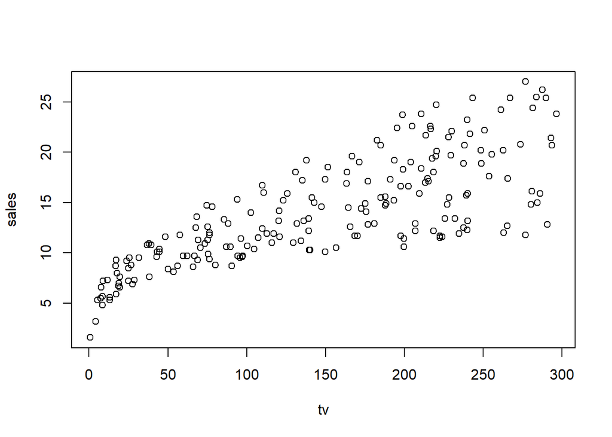

```r
sales <- advertising$sales
tv <- advertising$TV
radio <- advertising$radio
newspaper <- advertising$newspaper

plot(sales ~ tv)
```

#### 1.

$\beta_0$ and $\beta_1$ estimates:

```r
tv_mean <- mean(tv)
sales_mean <- mean(sales)
beta_hat_1 <- 0
beta_1_numer <- 0
beta_1_denom <- 0

for (i in 1:length(sales)){
  beta_1_numer <- beta_1_numer + (tv[i] - tv_mean) * (sales[i] - sales_mean)
  beta_1_denom <- beta_1_denom + (tv[i] - tv_mean)^2
}

beta_hat_1 <- (beta_1_numer / beta_1_denom)
print("beta_1 estimate")
```

```
## [1] "beta_1 estimate"
```

```r
beta_hat_1
```

```
## [1] 0.04753664
```

```r
beta_hat_0 <- sales_mean - (beta_hat_1*tv_mean)
print("beta_0 estimate")
```

```
## [1] "beta_0 estimate"
```

```r
beta_hat_0
```

```
## [1] 7.032594
```

```r
print("Values from lm()")
```

```
## [1] "Values from lm()"
```

```r
lm(sales~tv)
```

```
##
## Call:
## lm(formula = sales ~ tv)
##
## Coefficients:
## (Intercept)           tv
##     7.03259      0.04754
```

Standard Errors of estimates:

```r
s_num <- 0
n <- length(sales)

for (i in 1:length(sales)){
  s_num <- s_num + (sales[i] - (beta_hat_0 + (beta_hat_1*tv[i])))^2
}

s <- sqrt(s_num/(n-2))

denom <- 0

for (i in 1:length(sales)){
  denom <- denom + (tv[i] - tv_mean)^2
}

se_beta_hat_0 <- s * sqrt((1/n)+(tv_mean^2/denom))
print("se beta_0")
```

```
## [1] "se beta_0"
```

```r
se_beta_hat_0
```

```
## [1] 0.4578429
```

```r
se_beta_hat_1 <- s/sqrt(denom)
print("se beta_1")
```

```
## [1] "se beta_1"
```

```r
se_beta_hat_1
```

```
## [1] 0.002690607
```

```r
print("Values from lm()")
```

```
## [1] "Values from lm()"
```

```r
summary(lm(sales~tv))
```

```
##
## Call:
## lm(formula = sales ~ tv)
##
## Residuals:
##     Min      1Q  Median      3Q     Max
## -8.3860 -1.9545 -0.1913  2.0671  7.2124
##
## Coefficients:
##             Estimate Std. Error t value Pr(>|t|)
## (Intercept) 7.032594   0.457843   15.36   <2e-16 ***
## tv          0.047537   0.002691   17.67   <2e-16 ***
## ---
## Signif. codes:  0 '***' 0.001 '**' 0.01 '*' 0.05 '.' 0.1 ' ' 1
##
## Residual standard error: 3.259 on 198 degrees of freedom
## Multiple R-squared:  0.6119, Adjusted R-squared:  0.6099
## F-statistic: 312.1 on 1 and 198 DF,  p-value: < 2.2e-16
```

#### 2.

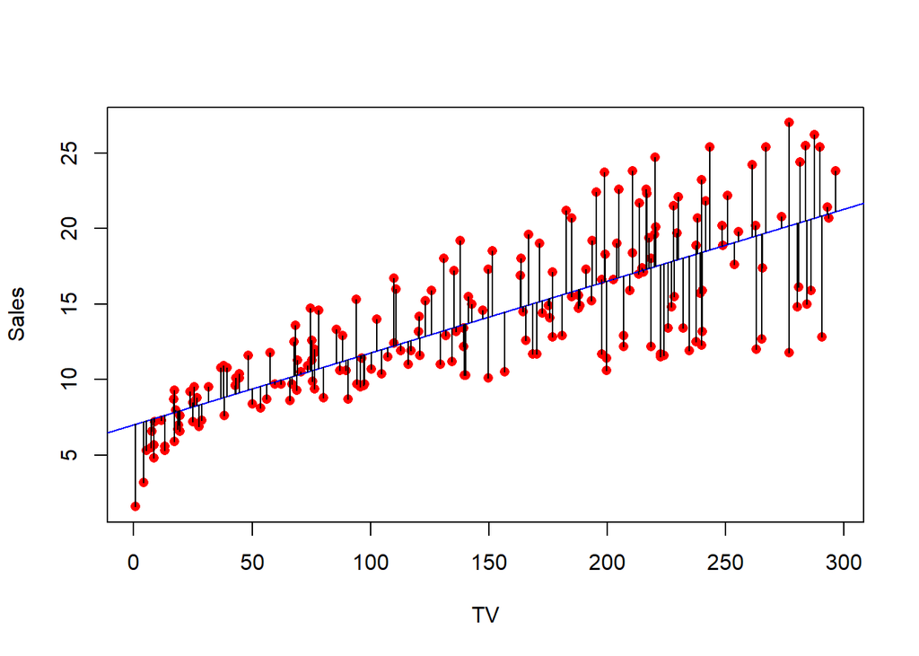

```r
plot(sales ~ tv, ylab = "Sales", xlab = "TV", col = "red", pch = 16)
abline(lm(sales~tv), col = "blue")
segments(tv, sales, tv, predict(lm(sales~tv)))
```

## Problem 2

```r
set.seed(2)

n.rep <- 1000
conf_int_b0 <- matrix(0, nrow=n.rep, ncol=2)
conf_int_b1 <- matrix(0, nrow=n.rep, ncol=2)

for (r in 1:n.rep){
  X <- rnorm(200, mean=0, sd=1)
  eps <- rnorm(200, mean=0, sd=4)
  Y <- 2 + 3*X + eps
  lm <- lm(Y~X)
  conf <- confint(lm)
  conf_int_b0[r,] <- conf[1,]
  conf_int_b1[r,] <- conf[2,]
}


print(mean(conf_int_b0[,1] < 2 & 2 < conf_int_b0[,2]))
```

```
## [1] 0.943
```

```r
print(mean(conf_int_b1[,1] < 3 & 3 < conf_int_b1[,2]))
```

```
## [1] 0.952
```

These confidence intervals contain our betas roughly 95% of the time, as expected.

## Problem 3

#### Sales onto Radio

```r
lm.radio <- lm(sales~radio)
summary(lm.radio)
```

```
##
## Call:
## lm(formula = sales ~ radio)
##
## Residuals:
##      Min       1Q   Median       3Q      Max
## -15.7305  -2.1324   0.7707   2.7775   8.1810
##
## Coefficients:
##             Estimate Std. Error t value Pr(>|t|)
## (Intercept)  9.31164    0.56290  16.542   <2e-16 ***
## radio        0.20250    0.02041   9.921   <2e-16 ***
## ---
## Signif. codes:  0 '***' 0.001 '**' 0.01 '*' 0.05 '.' 0.1 ' ' 1
##
## Residual standard error: 4.275 on 198 degrees of freedom
## Multiple R-squared:  0.332,  Adjusted R-squared:  0.3287
## F-statistic: 98.42 on 1 and 198 DF,  p-value: < 2.2e-16
```

1. HO: $\beta_{1}$ = 0 HA: $\beta_{1}$ =/= 0 $\alpha$ = .05

```r
summary(lm.radio)
```

```
##
## Call:
## lm(formula = sales ~ radio)
##
## Residuals:
##      Min       1Q   Median       3Q      Max
## -15.7305  -2.1324   0.7707   2.7775   8.1810
##
## Coefficients:
##             Estimate Std. Error t value Pr(>|t|)
## (Intercept)  9.31164    0.56290  16.542   <2e-16 ***
## radio        0.20250    0.02041   9.921   <2e-16 ***
## ---
## Signif. codes:  0 '***' 0.001 '**' 0.01 '*' 0.05 '.' 0.1 ' ' 1
##
## Residual standard error: 4.275 on 198 degrees of freedom
## Multiple R-squared:  0.332,  Adjusted R-squared:  0.3287
## F-statistic: 98.42 on 1 and 198 DF,  p-value: < 2.2e-16
```

With alpha at .05, we received a p-value of 2.2e-16 which gives us significant evidence to reject the null hypothesis in favor of the alternative that states that $\beta_{1}$ is not equal to 0. This gives us enough evidence to believe that there is some relationship between the predictor and the response.

2. Intercept: 9.31 Slope: .2025 Our intercept of 9.31 tells us when there is $0 invested in radio, sales should be at about 9,310 items sold. Our slope tells us that for every $1,000 invested in readio, there should be 202.5 more items sold.

```r
confint(lm.radio)
```

```
##                 2.5 %     97.5 %
## (Intercept) 8.2015885 10.4216877
## radio       0.1622443  0.2427472
```

We are 95% confident that when spending $1,000 more on radio there will be between 162.24 and 242.74 additional units sold

```r
prediction.radio <- 9.31 + (.2025 * 20)
prediction.radio
```

```
## [1] 13.36
```

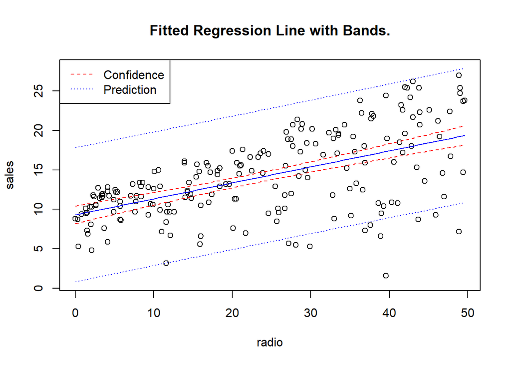

```r
pred.frame <- data.frame(radio=seq(min(radio), max(radio), length=100))
pp <- predict(lm.radio, int="p", newdata=pred.frame)
pc <- predict(lm.radio, int="c", newdata=pred.frame)
plot(radio ,sales, main="Fitted Regression Line with Bands.",
     ylim=range(sales, pp, na.rm=T))
matlines(pred.frame$radio, pc, lty=c(1,2,2), col=2)
matlines(pred.frame$radio, pp, lty=c(1,3,3), col=4)
legend("topleft",legend = c("Confidence","Prediction"), col=c(2,4), lty=c(2,3))
```

Based on our model, if we invested $20,000 into radio we would predict for there to be 13,360 items sold. The prediction bands are wider than the confidence bands because the confidence bands are the interval for which the average prediction can be found 95% of the time, whereas the prediction bands are wider because they contain 95% of the values of the observations.

5. Residual Standard Error (from summary()): 4.275 The standard deviation of the residuals is 4.275
6. R^2 = .332 33.2% of variance in sales is explained by radio advertisement spending

#### Sales onto Newspaper

```r
lm.newspaper <- lm(sales~newspaper)
summary(lm.newspaper)
```

```
##
## Call:
## lm(formula = sales ~ newspaper)
##
## Residuals:
##      Min       1Q   Median       3Q      Max
## -11.2272  -3.3873  -0.8392   3.5059  12.7751
##
## Coefficients:
##             Estimate Std. Error t value Pr(>|t|)
## (Intercept) 12.35141    0.62142   19.88  < 2e-16 ***
## newspaper    0.05469    0.01658    3.30  0.00115 **
## ---
## Signif. codes:  0 '***' 0.001 '**' 0.01 '*' 0.05 '.' 0.1 ' ' 1
##
## Residual standard error: 5.092 on 198 degrees of freedom
## Multiple R-squared:  0.05212,    Adjusted R-squared:  0.04733
## F-statistic: 10.89 on 1 and 198 DF,  p-value: 0.001148
```

1. HO: $\beta_{1}$ = 0 HA: $\beta_{1}$ =/= 0 $\alpha$ = .05

```r
summary(lm.newspaper)
```

```
##
## Call:
## lm(formula = sales ~ newspaper)
##
## Residuals:
##      Min       1Q   Median       3Q      Max
## -11.2272  -3.3873  -0.8392   3.5059  12.7751
##
## Coefficients:
##             Estimate Std. Error t value Pr(>|t|)
## (Intercept) 12.35141    0.62142   19.88  < 2e-16 ***
## newspaper    0.05469    0.01658    3.30  0.00115 **
## ---
## Signif. codes:  0 '***' 0.001 '**' 0.01 '*' 0.05 '.' 0.1 ' ' 1
##
## Residual standard error: 5.092 on 198 degrees of freedom
## Multiple R-squared:  0.05212,    Adjusted R-squared:  0.04733
## F-statistic: 10.89 on 1 and 198 DF,  p-value: 0.001148
```

With alpha at .05, we received a p-value of .001148 which gives us significant evidence to reject the null hypothesis in favor of the alternative that states that $\beta_{1}$ is not equal to 0. This gives us enough evidence to believe that there is some relationship between the predictor and the response.

```r
confint(lm.newspaper)
```

```
##                   2.5 %      97.5 %
## (Intercept) 11.12595560 13.57685854
## newspaper    0.02200549  0.08738071
```

```r
prediction.newspaper <- 12.3514 + (.05469 * 20)
prediction.newspaper
```

```
## [1] 13.4452
```

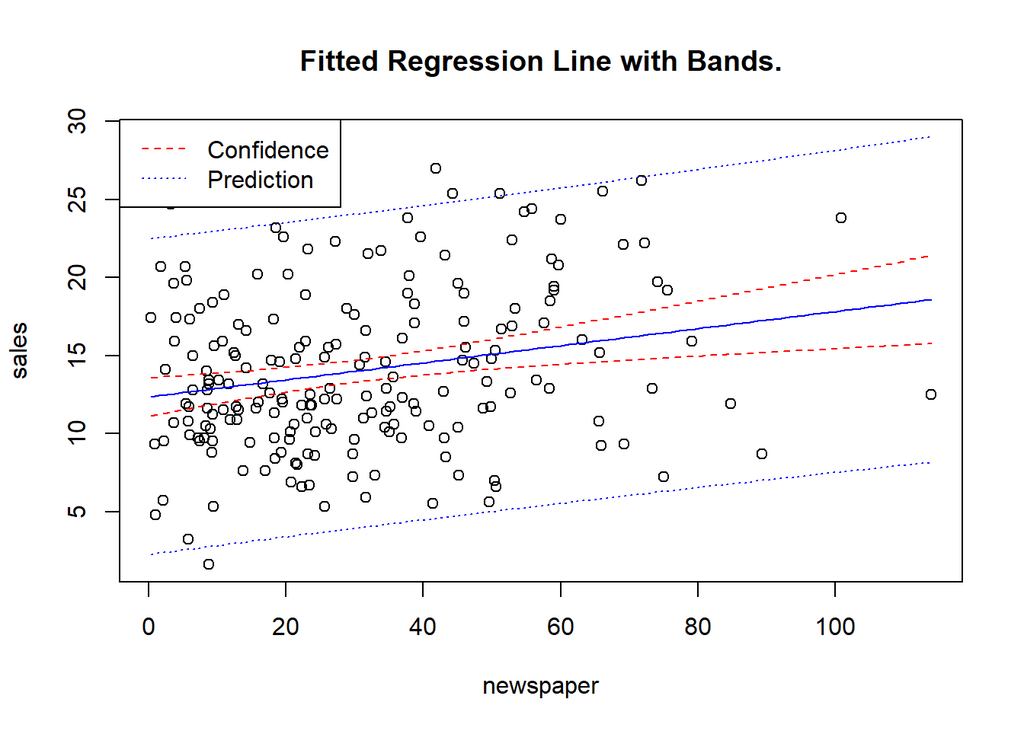

```r
pred.frame <- data.frame(newspaper=seq(min(newspaper), max(newspaper), length=100))
pp <- predict(lm.newspaper, int="p", newdata=pred.frame)
pc <- predict(lm.newspaper, int="c", newdata=pred.frame)
plot(newspaper,sales, main="Fitted Regression Line with Bands.",
     ylim=range(sales, pp, na.rm=T))
matlines(pred.frame$newspaper, pc, lty=c(1,2,2), col=2)
matlines(pred.frame$newspaper, pp, lty=c(1,3,3), col=4)
legend("topleft",legend = c("Confidence","Prediction"), col=c(2,4), lty=c(2,3))
```

Based on our model, if $20,000 was invested into newspaper we would predict for there to be 13,445 items sold. The prediction bands are wider than the confidence bands because the confidence bands are the interval for which the average prediction can be found 95% of the time, whereas the prediction bands are wider because they contain 95% of the values of the observations.

5. Residual standard error (from summary()): 5.092 The standard deviation of the residuals is 5.092
6. R^2 = .05212 5.2% of variance in sales is explained by newspaper advertisement spending